# Are Tenured Professors Mostly Men?

Example Final Project Writeup

Dr. Robinson

[figure not shown]

Google search results for “professor”

## Data Description

The data for this project come from end of semester student evaluations for a large sample of professors from The University of Texas at Austin. The original data set published in *Beauty in the Classroom* (Hamermesh & Parker, 2005) are available through the **openintro** `R` package.

For the Midterm Project, my analysis focused on the relationship between professor’s attractiveness and course evaluation scores, two numerical variables. For this analysis, however, I will be focusing on two categorical variables:

- professor’s self-identified sex (M / F)
- professor’s teaching rank (teaching / tenure track / tenured)

Specifically, I am interested in investigating if there are larger proportions of male-identifying faculty in tenured positions, whereas there are larger proportions of women in teaching positions.

## Data Visualization & Summarization

### Investigating Professor’s Self-Identified Sex

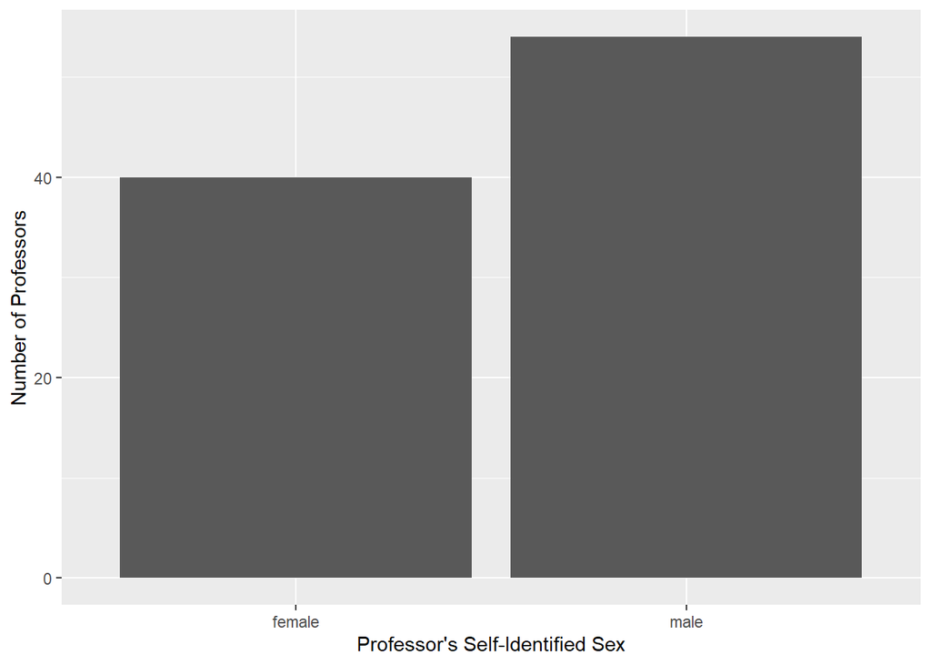

| sex | n |
| --- | --- |
| female | 40 |
| male | 54 |

In the bar plot of professor’s sex, we see that there are more male identifying professors than female identifying professors. Based on the summary table, we see there are 14 more male faculty than female faculty.

### Investigating Professor’s Teaching Rank

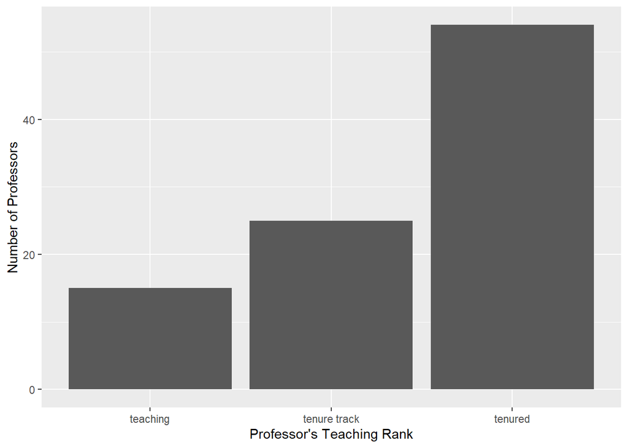

| rank | n |
| --- | --- |
| teaching | 15 |
| tenure track | 25 |
| tenured | 54 |

In the bar plot of professor’s teaching rank, we see the majority of faculty are tenured, over double the number of tenure track faculty at UT Austin. The smallest group is teaching faculty, with only 15 professors.

### Investigating the Relationship between Professor’s Self-Identified Sex and Teaching Rank

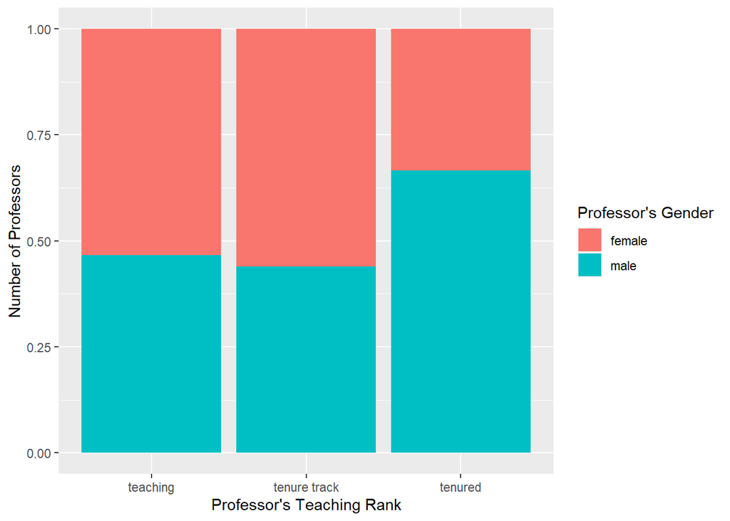

Based on the filled bar plot above, we can see that male professors make up a larger percentage of the tenured faculty than for all other teaching ranks. Contrary to what I expected, teaching and tenure track have about the same proportion of female faculty.

## Independence of Professor’s Sex and Teaching Rank

For our chi-squared analysis, we are interested in knowing if a professor’s sex is independent of their teaching rank. If there was no relationship between sex and teaching rank, we would expect to see approximately equal proportions of male identifying faculty across the teaching ranks.

### Model Conditions

To conduct a chi-squared analysis, there are two conditions required to be checked, (1) independence of observations and (2) expected cell counts of at least five for every level of sex and teaching rank.

As these professors were a convenience sample of professors at UT Austin, not a random sample, we need to think carefully about independence. There are no repeated observations of professors in the dataset and knowing the sex and rank of one faculty member doesn’t give you perfect information about another faculty member. Thus, I do not believe the independence of observations condition is violated.

The table of observed counts is shown below. The smallest observed counts are for female and male teaching faculty. To perform a parametric chi-squared analysis, we are required to have five expected counts in each cell of the table. Based on the table, we can see that the cell which should have the lowest expected count is female, teaching faculty. The expected count for this cell is $\frac{40 \times 15}{94} = 6.382$, which is larger than 5.

| rank | female | male | Total |
| --- | --- | --- | --- |
| teaching | 8 | 7 | 15 |
| tenure track | 14 | 11 | 25 |
| tenured | 18 | 36 | 54 |
| Total | 40 | 54 | 94 |

Since I have not seen any major violations of these conditions, I believe using a parametric chi-squared distribution will not incorrectly estimate the p-value for the test of independence.

### Chi-Squared Analysis

The results of the chi-squared analysis are presented below.

| statistic | chisq_df | p_value |
| --- | --- | --- |
| 4.440049 | 2 | 0.1086064 |

With a p-value of 0.109 (chi-squared statistic = 4.4 on 2 degrees of freedom), we have weak evidence against the null. At an $\alpha$ of 0.1 we fail to reject the null hypothesis of independence. Hence, these data do not suggest that a professor’s sex and their teaching rank are dependent.